# MATH 611 HW9

Jeff Gould

10/29/2020

```r
SampleCasino <- function(bigT){

  X_t <- c("Fair", rep(NA, bigT))

  for (j in 2:(bigT+1)) {
    if(X_t[j-1] == "Fair"){
      X_t[j] = sample(c("Fair", "Cheat"), 1, prob = c(0.95, 0.05))
    }else{
      X_t[j] = sample(c("Fair", "Cheat"), 1, prob = c(0.05, 0.95))
    }

  }

  Y_t <- sapply(X_t, function(x){
    if(x == "Fair"){
      return(sample(1:6, 1))
    }else{
      return(sample(1:6, 1, prob = c(49/250, 49/250, 49/250, 49/250, 49/250, 1/50)))
    }
  })

  return(data.frame(t = c(0:bigT),
                    X = X_t,
                    Y = Y_t))

}
set.seed(1234)
testSample <- SampleCasino(200)
```

## 1)

### a) Derive the forward algorithms for computing

$$\begin{equation}
\alpha_t = P(X(t) \ | \ Y(0), \dots, Y(t)).
\end{equation}$$

$\alpha_t = P(X(t)|Y(0), \dots ,Y(t)) = \frac{P(Y(0),\dots ,Y(t)|X(t))P(X(t))}{P(Y(0),\dots , Y(t))} = \frac{P(X(t), Y(0), \dots , Y(t))}{P(Y(0),\dots , Y(t))} =$

$\frac{p(Y(t)|X(t)) \sum_{X(t-1)} P(Y(0) \dots Y(t-1), X(t-1))P(X(t)|X(t-1))}{P(Y(0),\dots , Y(t))}$

Defining $c_n = P(Y(t) | Y(0), \dots Y(t-1))$, then

$P(Y(0),\dots , Y(t)) = \prod_{m=1}^n c_m$

$P(Y(t) | Y(0), \dots Y(t-1)) \rightarrow P(Y(t) | X(t-1)) = g_1(Y(t))(\alpha_{t-1}M)_1 + g_2(Y(t))(\alpha_{t-1}M)_2$

That is, given $Y(0), \dots Y(t-1))$, we calculated $P(X(t-1))$ in the previous step. From there, we calculate the probability of being in each state $i$ with $M$, and then the probability of $Y(t)$ in each state, $g_i(Y(t))$

```r
Forward <- function(Y, theta){

  M <- theta[["M"]]
  G <- theta[["G"]]
  pi <- theta[["pi"]]

  alpha <- matrix(NA, nrow = length(Y), ncol = nrow(M))

  C  <- sum(pi * G[,Y[1]])

  alpha[1, ] = G[, Y[1] ] * t(pi) / C

  for (t in 2:nrow(testSample)) {
    c_n <- alpha[t-1, ] %*% M %*% G[,Y[t]]
    C <- c(C, c_n)
    alpha[t, ] <- G[,Y[t]] * (alpha[t-1, ] %*% M) / as.numeric(c_n)
  }

  return(cbind(alpha, C))

}
```

### b) Backwards

$\beta_t = P(Y(t+1), Y(t+2), \dots Y(T) | X(t)) = \sum_{i=1}^2 P(Y(t+1), Y(t+2), \dots, Y(T), X(t)=i | X(t-1)) =$

$\sum_{i=1}^2 P(Y(t+1) \dots Y(T)|X(t), X(t+1)) P(X_{t+1}|X(t)) = \sum_{i=1}^2 P(Y(t+1) \dots Y(T)|X(t+1)) P(X_{t+1}|X(t)) =$

$\sum_{i=1}^2 P(Y(t+2), \dots ,Y(T)|X(t+1))P(Y(t+1)|X(t+1))P(X(t+1)|X(t)) \rightarrow$

$\beta_t = \sum_{X(t+1)} \beta_{t+1}P(Y(t+1)|X(t+1))P(X(t+1)|X(t))$

```r
Backward = function(Y, theta, C){

  M <- theta[["M"]]
  G <- theta[["G"]]
  bigT = length(Y)
  m = nrow(M)
  beta = matrix(1, bigT, m)

  for(t in (bigT-1):1){
    tmp = as.matrix(beta[t+1, ] * G[, Y[t+1]])
    beta[t, ] = t(M %*% tmp) / C[t+1]
  }
  return(beta)
}
```

### C

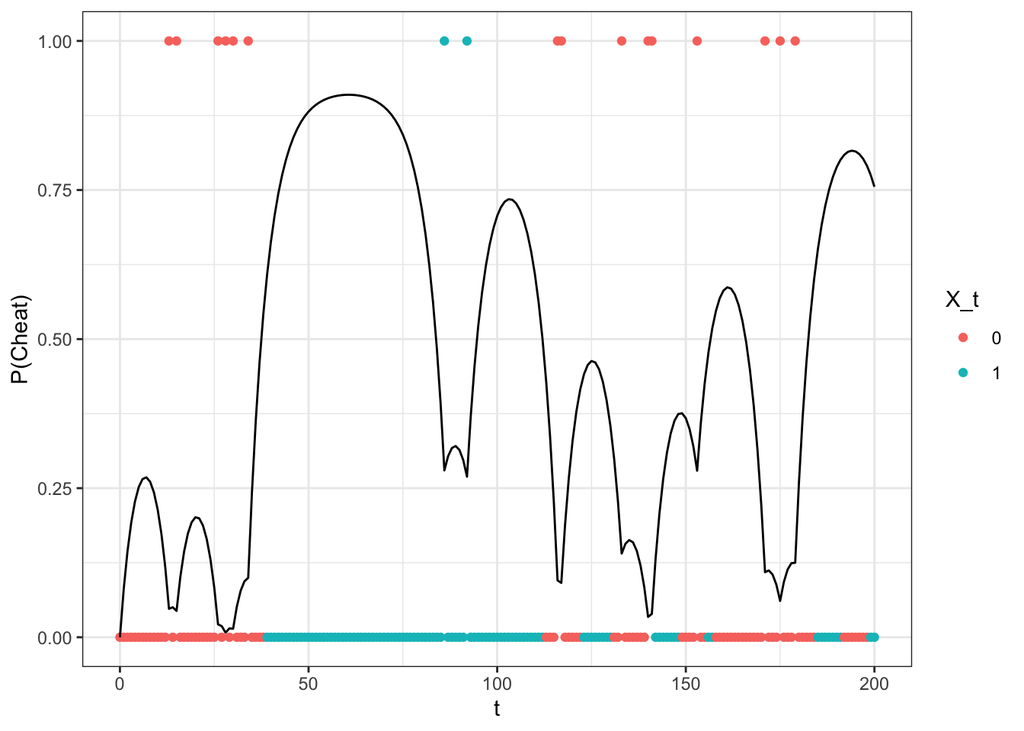

```r
ForwardBackward <- function(Y, theta){

  alpha <- Forward(Y = Y, theta = theta)
  C <- alpha[,3]
  alpha = alpha[,1:2]
  beta <- Backward(Y = Y, theta = theta, C = C)

  return(alpha * beta)

}

M <- matrix(c(0.95, 0.05, 0.05, 0.95), nrow = 2)

G <- matrix(c(rep(1/6, 6), rep(49/250, 5), 1/50), nrow = 2, byrow = T)

pi <- matrix(c(1,0), nrow = 2)

theta <- list(M = M,
              G = G,
              pi = pi)

Y <- testSample$Y


probs <- ForwardBackward(Y = Y, theta = theta)

results <- data.frame(p_cheating = probs[,2],
                      Y_t = testSample$Y,
                      X_t = as.numeric(testSample$X == "Cheat"),
                      t = seq(0, 200))

results %>%
  mutate(is_6 = ifelse(Y_t == 6, 1, 0),
         X_t = as.factor(X_t)) %>%
  ggplot(aes(x = t)) +
  geom_point(aes(y = is_6, color = X_t)) +
  theme_bw() +
  geom_line(aes(y =  p_cheating)) +
  labs( y = "P(Cheat)")
```

Here the line represents the probabilty that the casino is cheating, the points indicate whether or not a 6 was rolled (1-5 is plotted at 0, 6 is plotted at 1), and the color of the point indicates whether or not the casino was cheating.

Here is the graph from HW8 for comparison. We see that they are very similar, but also that the Forward-Backward algorithm worked better to capture the cheating at the end boundary

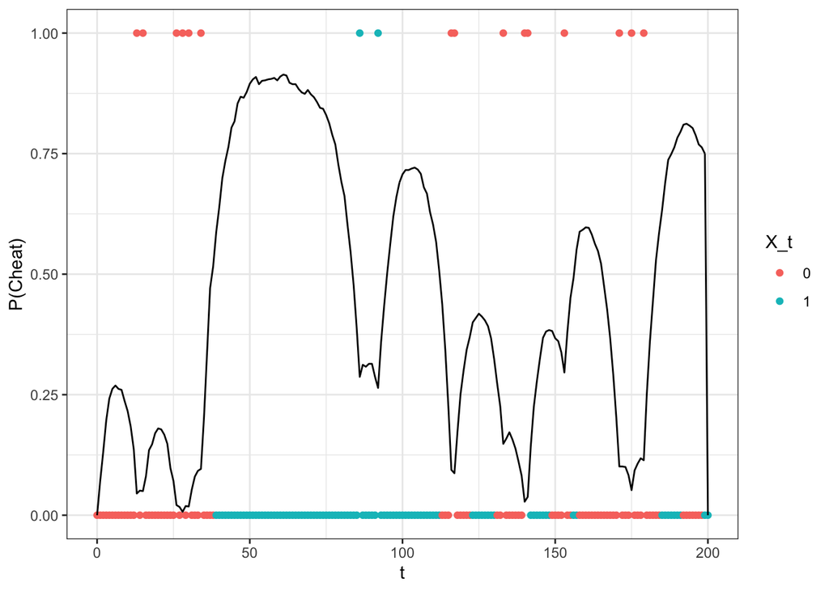

## 2

Consider the continuous state Markov chain $X(t+1) = r X(t) + \mathcal{N}(0, \sigma^2)$. Assume $X(0) =x_0 \in \mathbb{R}$.

### a)

Explain why $X(t)$ is always normally distributed. Then compute the mean and variance of $X(t)$. (Hint: you can express the mean and variances of $X(t)$ in terms of the mean and variances of $X(t-1)$.

Given $X(0) = x_0$, then $X(1) = r x_0 + \mathcal{N}(0, \sigma^2) = \mathcal{N}(r x_0, \sigma^2)$

Suppose we know $X(t-1)$. Then $X(t) = r X(t-1) + \mathcal{N}(0, \sigma^2) = \mathcal{N}(r X(t-1), \sigma^2)$

So $X(t)$ is always normally distributed with $\mu = rX(T-1)$ and $\sigma^2 = \sigma^2$

Furthermore, we can say that $\mu_t = r^tx_0$

$E[X(2)] = rX(1) + \mathcal{N}(0, \sigma^2) = E[r( r x_0 + \mathcal{N}(0, \sigma^2)) + \mathcal{N}(0, \sigma^2)] = E[r^2x_0 + r \mathcal{N}(0, \sigma^2)) + \mathcal{N}(0, \sigma^2))] = r^2x_0$

Now suppose $E[X(t-1)] = r^{t-1}x_0$. Then $E[X(t)] = E[rX(t-1) + \mathcal{N}(0, \sigma^2))] = E[rX(t-1)] + E[\mathcal{N}(0, \sigma^2))] = rE[X(t-1)] = r^tx_0$

$X(t) \sim \mathcal{N}(r^tx_0, \sigma^2))$